# We have opted for the Literate Programming approach to present our project this semester, which is based on *Sentiment Analysis* using the *Python NLTK* library

### This jupyter notebook showcases the various Techniques and Libraries we have relied upon for the Project.

##### The index of what we are to cover in this notebook are as follows

# Overview

### India

[figure not shown]

## States

[figure not shown]

### The Timeline of Bans

[figure not shown]

### Nature of Bans

[figure not shown]

# NLTK and Twitter

### The Live Twitter Feed ( Modify This!)

###### NOTE Must hit the < Interrupt Kernel > button, for there intrinsic filter lacks a time boundation

```python
from tweepy import Stream
from tweepy import OAuthHandler
from tweepy.streaming import StreamListener

ckey='pD6v5kfp67FXY2NASfowDazRJ'
csecret='7iZO2rFiMDUwOqOfQVJF4RfVxbQtoapQ1eTMUeFs1e8szTaDVy'

# The access tokens can be found on your applications's Details
# page located at https://dev.twitter.com/apps (located
# under "Your access token")
atoken='3414048620-HZauU3mJwiI7TBrUluFGCPKn4k4UdZviNty6KcD'
asecret='OlZbg7WTAThOnnMHpWKfK82XOKbZ2Sx0Kh082r7uGb3PX'

# Tweepy

class listener(StreamListener):
    def on_data (self, data):
        print(data)
        return True

    def on_error(self, status):
        print(status)

auth = OAuthHandler(ckey, csecret)
auth.set_access_token(atoken, asecret)


import time

start_time = time.time()
ls = []
while True:
    twitterStream = Stream(auth, listener())
    ls.append(twitterStream.filter(track = ["car"]))

    if(( time.time() - start_time ) < 0.009):
           break
```

[output not shown]

[output not shown]

[output cut: 46 more lines]

[output not shown]

# Importing various modules from the NLTK platform

### NLTK - Natural Language processing Tool Kit

```python
import nltk
from nltk.probability import ELEProbDist, FreqDist, DictionaryProbDist
from nltk import NaiveBayesClassifier
from nltk import FreqDist, ConditionalFreqDist
from nltk import BigramAssocMeasures
from collections import defaultdict
```

## Applying it to the tweets to understand the sentiment.

```python
pos_tweets = [('Attention all Nature Lovers - Cattle Cruelty in India & Rescues', 'positive'),
              ('Are you having debate on Poojari Lynching for try to save cow slaughter?', 'positive'),
              ('Hope People start loving all animals like this & not show', 'positive'),
              ('if slaughter houses had glass walls everyone would be a vegetarian', 'positive'),
              ('BanBeef SayNOtoMEATexport PlunderOfIndia SaveGauVansh Cow Vegetarian JagoBharathJag', 'positive'),
              ('I will eat beef and pork for religious reasons, occasionally. I will be vegetarian for ethical reasons, frequently. #meatban #vegetarian','positive')
]

neg_tweets = [('Let try to ban hunger before we ban meat?', 'negative'),
              ('meatban causing price of pulses at 200+/kg', 'negative'),
              ('Where is Indian Politics heading to? Chicken, mutton or beef now parliament will approve the dinner', 'negative'),
              ('There is something truly secretly delicious about having your mouth enjoy a perfect BLT in a country with meat ban', 'negative'),
              ('We will let loose 100 pigs in Jama Masjid if the meatban was not enforced on 9 days of Navratri', 'negative')]


test_tweet = [('A Question: Can someone please tell me how jhatka came into being in answer to halal in India? Please enlighten','negative')]

tweets = []
for (words, sentiment) in pos_tweets + neg_tweets:
    words_filtered = [e.lower() for e in words.split()
if len(e) >= 3]
    tweets.append((words_filtered, sentiment))
#print(tweets)

test_tweets = []
for (words, sentiment) in test_tweet:
    words_filtered = [e.lower() for e in words.split()
if len(e) >= 3]
    test_tweets.append((words_filtered, sentiment))
#print(test_tweets)

def get_words_in_tweets(tweets):
    all_words = []
    for (words, sentiment) in tweets:
        all_words.extend(words)
    return all_words

def get_word_features(wordlist):
    wordlist = nltk.FreqDist(wordlist)
    word_features = wordlist.keys()
    return word_features


word_features = get_word_features(get_words_in_tweets(tweets))
#print(word_features)

def extract_features(document):
    document_words = set(document)
    features = {}
    for word in word_features:
        features['contains(%s)' % word] = (word in document_words)
    return features

a = extract_features(test_tweet)
print(a)

training_set = nltk.classify.apply_features(extract_features, tweets)
print(training_set)
classifier = nltk.NaiveBayesClassifier.train(training_set)

def train(labeled_featuresets, estimator= ELEProbDist):
    ...
    # Create the P(label) distribution
    label_freqdist = ConditionalFreqDist()
    label_probdist = estimator(label_freqdist)
    ...
    # Create the P(fval|label, fname) distribution
    feature_probdist = {}
    ...
    return NaiveBayesClassifier(label_probdist, feature_probdist)
    #!print(label_probdist.prob('positive'))
    #!print(feature_probdist)

print(classifier.show_most_informative_features(32))

#tweet = 'Meat Ban reminds me of TV Ban. If one of your siblings was taking the board exams, you cannot watch too'
        #'And I support Cow,Buffalo #meatban if #India returns to #Swadeshi #agriculture Invest in Agriculture to #SaveIndia'
#print(classifier.classify(extract_features(tweet.split())))
```

```
{'contains(to?)': False, 'contains(cruelty)': False, 'contains(try)': False, 'contains(and)': False, 'contains(ethical)': False, 'contains(frequently.)': False, 'contains(are)': False, 'contains(200+/kg)': False, 'contains(people)': False, 'contains(where)': False, 'contains(truly)': False, 'contain…
[({'contains(to?)': False, 'contains(cruelty)': True, 'contains(try)': False, 'contains(and)': False, 'contains(ethical)': False, 'contains(frequently.)': False, 'contains(are)': False, 'contains(200+/kg)': False, 'contains(people)': False, 'contains(where)': False, 'contains(truly)': False, 'contai…
Most Informative Features
          contains(will) = True           negati : positi =      1.9 : 1.0
    contains(vegetarian) = False          negati : positi =      1.8 : 1.0
       contains(meatban) = False          positi : negati =      1.6 : 1.0
           contains(let) = False          positi : negati =      1.6 : 1.0
           contains(the) = False          positi : negati =      1.6 : 1.0
           contains(ban) = False          positi : negati =      1.6 : 1.0
           contains(cow) = False          negati : positi =      1.4 : 1.0
           contains(all) = False          negati : positi =      1.4 : 1.0
           contains(for) = False          negati : positi =      1.4 : 1.0
          contains(will) = False          positi : negati =      1.3 : 1.0
        contains(before) = False          positi : negati =      1.2 : 1.0
      contains(secretly) = False          positi : negati =      1.2 : 1.0
           contains(was) = False          positi : negati =      1.2 : 1.0
         contains(loose) = False          positi : negati =      1.2 : 1.0
        contains(dinner) = False          positi : negati =      1.2 : 1.0
      contains(enforced) = False          positi : negati =      1.2 : 1.0
         contains(enjoy) = False          positi : negati =      1.2 : 1.0
        contains(indian) = False          positi : negati =      1.2 : 1.0
       contains(country) = False          positi : negati =      1.2 : 1.0
         contains(mouth) = False          positi : negati =      1.2 : 1.0
         contains(price) = False          positi : negati =      1.2 : 1.0
      contains(navratri) = False          positi : negati =      1.2 : 1.0
     contains(delicious) = False          positi : negati =      1.2 : 1.0
          contains(days) = False          positi : negati =      1.2 : 1.0
         contains(there) = False          positi : negati =      1.2 : 1.0
         contains(where) = False          positi : negati =      1.2 : 1.0
          contains(jama) = False          positi : negati =      1.2 : 1.0
         contains(meat?) = False          positi : negati =      1.2 : 1.0
    contains(parliament) = False          positi : negati =      1.2 : 1.0
           contains(now) = False          positi : negati =      1.2 : 1.0
     contains(something) = False          positi : negati =      1.2 : 1.0
           contains(blt) = False          positi : negati =      1.2 : 1.0
None
```

# Datasets and Pandas

## Let us first consider the composition of this term's Government

### Move to the datasets directory

```python
import os
#os.chdir("/home/archimedeas/wrkspc/anaconda/the-visual-verdict/visualizations/1_the_senate/datasets")
os.getcwd()
```

[output not shown]

```python
os.listdir()
```

```
['Ban Spreadsheet.csv',
 'originals',
 'processed_census_datasets',
 'the_senate_datasets',
 'tweepy-master']
```

```python
os.chdir('..')
```

```python
os.getcwd()
os.chdir('the_senate_datasets')
```

## List of DataSets

```python
os.listdir()
```

```
['10_women_occupation.csv',
 '11_women_first_time.csv',
 '1_age_group_5yr_span.csv',
 '2_avg_age_lok_sabha_16_sessions.csv',
 '3_age_group_first_time_member.csv',
 '4_educational_background.csv',
 '5_occupational_background.csv',
 '6_first_time_elected.csv',
 '7_women_member_per_state.csv',
 '8_women_age_group.csv',
 '9_educational_qual_women.csv']
```

### Now we read in the CSV files using the Pandas Dataset

```python
import pandas as pd
df_men = pd.read_csv("1_age_group_5yr_span.csv")
df_men
```

|  | Table - 1 Distribution of Age Groups of members with 5 year span | Unnamed: 1 |
| --- | --- | --- |
| 0 | Year-Space | No of Members |
| 1 | 25-30 | 12 |
| 2 | 31-35 | 21 |
| 3 | 36-40 | 36 |
| 4 | 41-45 | 58 |
| 5 | 46-50 | 70 |
| 6 | 51-55 | 87 |
| 7 | 55-60 | 92 |
| 8 | 61-65 | 83 |
| 9 | 66-70 | 43 |
| 10 | 71-75 | 28 |
| 11 | 76-80 | 11 |
| 12 | 81-85 | 1 |
| 13 | 86-90 | 1 |

## Converting this dataset to a suitable format

1. For the purpose of using various fields as labels in matplotlib
2. We use numpy for the same

## Visual representation of the Information

## Changing the default style sheet for matplotlib

```python
%matplotlib inline
import matplotlib.pyplot as plt
plt.style.use('ggplot')
plt.rcParams['figure.figsize'] = (10.0, 8.0)
```

```python
ls_labels_men = []
ls_values_men = []

for i in range(1,df_men.shape[0]):
    ls_labels_men.append(str(df_men.iat[i,0]))
    ls_values_men.append(float(df_men.iat[i,1]))
```

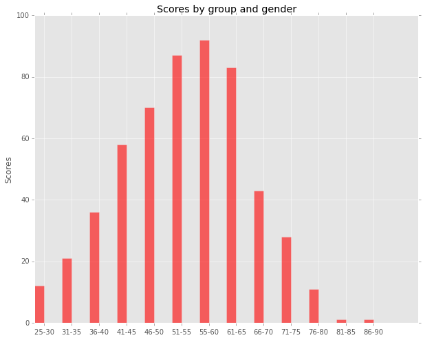

```python
import numpy as np
import matplotlib.pyplot as plt

N = len(ls_labels_men)


ind = np.arange(N)  # the x locations for the groups
width = 0.35       # the width of the bars

fig, ax = plt.subplots()

rects1 = ax.bar(ind, ls_values_men, width, color = 'red', alpha = 0.6)



#rects2 = ax.bar(ind + width, ls_values_men, width )

# add some text for labels, title and axes ticks
ax.set_ylabel('Scores')

ax.set_title('Scores by group and gender')
ax.set_xticks(ind + width)
ax.set_xticklabels(ls_labels_men)


#ax.legend((rects1[0], rects2[0]), ('Men', 'Women'))

plt.show()
```

```python
import pandas as pd
df_men = pd.read_csv("4_educational_background.csv")
```

```python
df_men
```

|  | Table - 4 Educational Background of Members | Unnamed: 1 | Unnamed: 2 |
| --- | --- | --- | --- |
| 0 | Educational Qualifications | No. of Members | Percentage |
| 1 | Under Matriculates/Certified Courses/ Others | 17 | 3.13 |
| 2 | Matric, Inter/High Secondary, Diploma Holders | 92 | 16.95 |
| 3 | Under Graduates | 15 | 2.77 |
| 4 | Graduates includeing those with equivalent tec... | 226 | 41.62 |
| 5 | Post Graduates including those with equivalent... | 160 | 29.46 |
| 6 | Doctorate | 33 | 6.07 |

```python
ls_labels_men = []
ls_values_men = []

for i in range(1,df_men.shape[0]):
    ls_labels_men.append(str(df_men.iat[i,0]))
    ls_values_men.append(float(df_men.iat[i,1]))
```

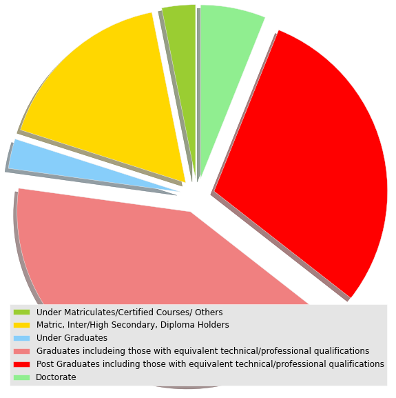

```python
import matplotlib.pyplot as plt
import pandas as pd
plt.rcParams['figure.figsize'] = (10.0, 10.0)

# The slices will be ordered and plotted counter-clockwise.

labels = ls_labels_men
sizes = ls_values_men
colors = ['yellowgreen', 'gold', 'lightskyblue', 'lightcoral', 'red', 'lightgreen']
explode = (0.1, 0.1, 0.1, 0.1, 0.1, .1)

p, text = plt.pie(sizes,  colors = colors, explode =  explode, shadow=True, startangle=90 )
# Set aspect ratio to be equal so that pie is drawn as a circle.
plt.axis('equal')

#plt.title("Educational Background", fontsize = 50, loc = 'right')

plt.legend(p, labels, loc= 'lower right')

plt.show()
```

## Similarly we have analysed the census data for education, populatin, literacy rates etc for the country

```python
os.getcwd()
```

[output not shown]

```python
os.chdir('..')
```

```python
os.getcwd()
```

[output not shown]

```python
os.chdir('processed_census_datasets')
```

```python
import pandas as pd
df = pd.read_csv("processed-population-and-education_DDW-0000C-10.xlsx - C-10 SC.csv")
df
```

|  | Unnamed: 0 | Unnamed: 1 | Unnamed: 2 | Unnamed: 3 | Unnamed: 4 | C-10 : POPULATION ATTENDING EDUCATIONAL INSTITUTIONS BY AGE, SEX AND TYPE OF EDUCATIONAL INSTITUTION - 2011 | Unnamed: 6 | Unnamed: 7 | Unnamed: 8 | Unnamed: 9 | ... | Unnamed: 26 | Unnamed: 27 | Unnamed: 28 | Unnamed: 29 | Unnamed: 30 | Unnamed: 31 | Unnamed: 32 | Unnamed: 33 | Unnamed: 34 | Unnamed: 35 |
| --- | --- | --- | --- | --- | --- | --- | --- | --- | --- | --- | --- | --- | --- | --- | --- | --- | --- | --- | --- | --- | --- |
| 0 | Table | State | Distt. | Area Name | Total/ | Age- | Total population | NaN | NaN | Population | ... | NaN | NaN | NaN | NaN | Population not attending educational institutions | NaN | NaN | NaN | NaN | NaN |
| 1 | Name | Code | Code | NaN | Rural/ | group | NaN | NaN | NaN | attending educational institutions | ... | NaN | Other institution | NaN | NaN | Attended Before | NaN | NaN | Never Attended | NaN | NaN |
| 2 | NaN | NaN | NaN | NaN | Urban/ | NaN | Persons | Males | Females | Persons | ... | Females | Persons | Males | Females | Persons | Males | Females | Persons | Males | Females |
| 3 | NaN | NaN | NaN | NaN | NaN | 1 | 2 | 3 | 4 | 5 | ... | 22 | 23 | 24 | 25 | 26 | 27 | 28 | 29 | 30 | 31 |
| 4 | NaN | NaN | NaN | NaN | NaN | NaN | NaN | NaN | NaN | NaN | ... | NaN | NaN | NaN | NaN | NaN | NaN | NaN | NaN | NaN | NaN |
| 5 | NaN | NaN | NaN | NaN | NaN | NaN | NaN | NaN | NaN | NaN | ... | NaN | NaN | NaN | NaN | NaN | NaN | NaN | NaN | NaN | NaN |
| 6 | C3010 | 0 | 0 | INDIA | Total | All ages | 1210854977 | 623270258 | 587584719 | 314556926 | ... | 846217 | 1023291 | 556681 | 466610 | 481187692 | 279953000 | 201234692 | 415110359 | 172779827 | 242330532 |
| 7 | C3010 | 0 | 0 | INDIA | Rural | All ages | 833748852 | 427781058 | 405967794 | 214744835 | ... | 712212 | 595972 | 318582 | 277390 | 290282165 | 175224339 | 115057826 | 328721852 | 135648574 | 193073278 |
| 8 | C3010 | 0 | 0 | INDIA | Urban | All ages | 377106125 | 195489200 | 181616925 | 99812091 | ... | 134005 | 427319 | 238099 | 189220 | 190905527 | 104728661 | 86176866 | 86388507 | 37131253 | 49257254 |
| 9 | C3010 | 1 | 0 | State - JAMMU & KASHMIR | Total | All ages | 12541302 | 6640662 | 5900640 | 3696633 | ... | 1382 | 27380 | 16518 | 10862 | 3772010 | 2439586 | 1332424 | 5072659 | 2177376 | 2895283 |
| 10 | C3010 | 1 | 0 | State - JAMMU & KASHMIR | Rural | All ages | 9108060 | 4774477 | 4333583 | 2676870 | ... | 907 | 13592 | 8977 | 4615 | 2369581 | 1561745 | 807836 | 4061609 | 1735005 | 2326604 |
| 11 | C3010 | 1 | 0 | State - JAMMU & KASHMIR | Urban | All ages | 3433242 | 1866185 | 1567057 | 1019763 | ... | 475 | 13788 | 7541 | 6247 | 1402429 | 877841 | 524588 | 1011050 | 442371 | 568679 |
| 12 | C3010 | 3 | 0 | State - PUNJAB | Total | All ages | 27743338 | 14639465 | 13103873 | 6801164 | ... | 4336 | 36724 | 17065 | 19659 | 12745862 | 7123202 | 5622660 | 8196312 | 3759685 | 4436627 |
| 13 | C3010 | 3 | 0 | State - PUNJAB | Rural | All ages | 17344192 | 9093476 | 8250716 | 4182696 | ... | 2807 | 17453 | 7910 | 9543 | 7325234 | 4115714 | 3209520 | 5836262 | 2664860 | 3171402 |
| 14 | C3010 | 3 | 0 | State - PUNJAB | Urban | All ages | 10399146 | 5545989 | 4853157 | 2618468 | ... | 1529 | 19271 | 9155 | 10116 | 5420628 | 3007488 | 2413140 | 2360050 | 1094825 | 1265225 |
| 15 | C3010 | 7 | 0 | State - NCT OF DELHI | Total | All ages | 16787941 | 8987326 | 7800615 | 4717065 | ... | 1821 | 29129 | 16621 | 12508 | 8416894 | 4812396 | 3604498 | 3653982 | 1584957 | 2069025 |
| 16 | C3010 | 7 | 0 | State - NCT OF DELHI | Rural | All ages | 419042 | 226321 | 192721 | 121535 | ... | 64 | 591 | 311 | 280 | 185424 | 111001 | 74423 | 112083 | 46574 | 65509 |
| 17 | C3010 | 7 | 0 | State - NCT OF DELHI | Urban | All ages | 16368899 | 8761005 | 7607894 | 4595530 | ... | 1757 | 28538 | 16310 | 12228 | 8231470 | 4701395 | 3530075 | 3541899 | 1538383 | 2003516 |
| 18 | C3010 | 9 | 0 | State - UTTAR PRADESH | Total | All ages | 199812341 | 104480510 | 95331831 | 57397639 | ... | 57981 | 170034 | 93597 | 76437 | 61343576 | 38702160 | 22641416 | 81071126 | 34355911 | 46715215 |
| 19 | C3010 | 9 | 0 | State - UTTAR PRADESH | Rural | All ages | 155317278 | 80992995 | 74324283 | 44660839 | ... | 44855 | 103705 | 53921 | 49784 | 43954328 | 28710787 | 15243541 | 66702111 | 27761497 | 38940614 |
| 20 | C3010 | 9 | 0 | State - UTTAR PRADESH | Urban | All ages | 44495063 | 23487515 | 21007548 | 12736800 | ... | 13126 | 66329 | 39676 | 26653 | 17389248 | 9991373 | 7397875 | 14369015 | 6594414 | 7774601 |
| 21 | C3010 | 10 | 0 | State - BIHAR | Total | All ages | 104099452 | 54278157 | 49821295 | 28365229 | ... | 158407 | 136148 | 67884 | 68264 | 26855076 | 17136181 | 9718895 | 48879147 | 21384073 | 27495074 |
| 22 | C3010 | 10 | 0 | State - BIHAR | Rural | All ages | 92341436 | 48073850 | 44267586 | 24671221 | ... | 151553 | 116961 | 57056 | 59905 | 22551179 | 14657142 | 7894037 | 45119036 | 19694374 | 25424662 |
| 23 | C3010 | 10 | 0 | State - BIHAR | Urban | All ages | 11758016 | 6204307 | 5553709 | 3694008 | ... | 6854 | 19187 | 10828 | 8359 | 4303897 | 2479039 | 1824858 | 3760111 | 1689699 | 2070412 |
| 24 | C3010 | 18 | 0 | State - ASSAM | Total | All ages | 31205576 | 15939443 | 15266133 | 7548916 | ... | 5726 | 18000 | 10881 | 7119 | 12432989 | 7057632 | 5375357 | 11223671 | 4979617 | 6244054 |
| 25 | C3010 | 18 | 0 | State - ASSAM | Rural | All ages | 26807034 | 13678989 | 13128045 | 6423680 | ... | 5195 | 13304 | 8338 | 4966 | 9962844 | 5726720 | 4236124 | 10420510 | 4631948 | 5788562 |
| 26 | C3010 | 18 | 0 | State - ASSAM | Urban | All ages | 4398542 | 2260454 | 2138088 | 1125236 | ... | 531 | 4696 | 2543 | 2153 | 2470145 | 1330912 | 1139233 | 803161 | 347669 | 455492 |
| 27 | C3010 | 19 | 0 | State - WEST BENGAL | Total | All ages | 91276115 | 46809027 | 44467088 | 20857818 | ... | 126983 | 76249 | 43086 | 33163 | 42496443 | 23897571 | 18598872 | 27921854 | 12082218 | 15839636 |
| 28 | C3010 | 19 | 0 | State - WEST BENGAL | Rural | All ages | 62183113 | 31844945 | 30338168 | 14434107 | ... | 105788 | 40592 | 24341 | 16251 | 26090469 | 15024391 | 11066078 | 21658537 | 9340722 | 12317815 |
| 29 | C3010 | 19 | 0 | State - WEST BENGAL | Urban | All ages | 29093002 | 14964082 | 14128920 | 6423711 | ... | 21195 | 35657 | 18745 | 16912 | 16405974 | 8873180 | 7532794 | 6263317 | 2741496 | 3521821 |
| 30 | C3010 | 24 | 0 | State - GUJARAT | Total | All ages | 60439692 | 31491260 | 28948432 | 14320617 | ... | 16550 | 23440 | 13686 | 9754 | 28356858 | 16250612 | 12106246 | 17762217 | 7206427 | 10555790 |
| 31 | C3010 | 24 | 0 | State - GUJARAT | Rural | All ages | 34694609 | 17799159 | 16895450 | 8102296 | ... | 12977 | 11388 | 6948 | 4440 | 14317218 | 8443925 | 5873293 | 12275095 | 4834504 | 7440591 |
| 32 | C3010 | 24 | 0 | State - GUJARAT | Urban | All ages | 25745083 | 13692101 | 12052982 | 6218321 | ... | 3573 | 12052 | 6738 | 5314 | 14039640 | 7806687 | 6232953 | 5487122 | 2371923 | 3115199 |
| 33 | C3010 | 27 | 0 | State - MAHARASHTRA | Total | All ages | 112374333 | 58243056 | 54131277 | 29474864 | ... | 54642 | 67881 | 38110 | 29771 | 55603074 | 31085636 | 24517438 | 27296395 | 11127800 | 16168595 |
| 34 | C3010 | 27 | 0 | State - MAHARASHTRA | Rural | All ages | 61556074 | 31539034 | 30017040 | 16201903 | ... | 40866 | 28439 | 15114 | 13325 | 27210847 | 15558963 | 11651884 | 18143324 | 7149532 | 10993792 |
| 35 | C3010 | 27 | 0 | State - MAHARASHTRA | Urban | All ages | 50818259 | 26704022 | 24114237 | 13272961 | ... | 13776 | 39442 | 22996 | 16446 | 28392227 | 15526673 | 12865554 | 9153071 | 3978268 | 5174803 |
| 36 | C3010 | 28 | 0 | State - ANDHRA PRADESH | Total | All ages | 84580777 | 42442146 | 42138631 | 21701636 | ... | 98659 | 95981 | 49204 | 46777 | 31253843 | 17665590 | 13588253 | 31625298 | 13042707 | 18582591 |
| 37 | C3010 | 28 | 0 | State - ANDHRA PRADESH | Rural | All ages | 56361702 | 28243241 | 28118461 | 13660166 | ... | 74039 | 56085 | 27830 | 28255 | 18356718 | 10721909 | 7634809 | 24344818 | 10045101 | 14299717 |
| 38 | C3010 | 28 | 0 | State - ANDHRA PRADESH | Urban | All ages | 28219075 | 14198905 | 14020170 | 8041470 | ... | 24620 | 39896 | 21374 | 18522 | 12897125 | 6943681 | 5953444 | 7280480 | 2997606 | 4282874 |

39 rows × 36 columns

```python
df.shape
```

```
(39, 36)
```

## Other Datasets fom the Census 2011 survey

```python
os.listdir()
```

```
['processed-education-level_DDW-0000C-08.xlsx - C-08.csv',
 'processed-graduate-and-above_DDW-0000C-08A.xlsx - C-08App.csv',
 'processed-household-size_DDW-HH01-0000-2011.XLS - Sheet1.csv',
 'processed-non-worker_DDW-0000B-13-Census.xls - B13.csv',
 'processed-population-and-education_DDW-0000C-10.xlsx - C-10 SC.csv',
 'processed-population-and-religion_DDW00C-01_20MDDS.XLS - C01.csv',
 'processed-workforce-analysis_DDW-0000B-01-Census.xls - B01.csv',
 'processed-youth-population_PCA_AY_2011_Revised.xlsx - Sheet1.csv']
```

# Various Visualization Techniques

## Matplotlib has been introduced earlier

# Using Bokeh

### Here we represent the Parameters wrt National level and State level.

### Namely, of two states Delhi and Assam

```python
from bokeh._legacy_charts import Bar
from bokeh.io import output_notebook, show

# get the countries and we group the data by medal type
states = ['delhi', 'assam']


delhi = [ [56,46],
         [23,77],
         [45,55],
         [60,40],
         [35,15,25,25]
]

assam = [ [30,10],
         [33,67],
         [75,25],
         [50,50],
         [75,5,10,10]
]

output_notebook()

bar = Bar([delhi[0],assam[0]], states, title="Stacked bars", stacked=True)
bar2 = Bar([delhi[0],assam[0]], states, title="Stacked bars")

show(bar)
```

BokehJS successfully loaded.

## A Tale of Two Cities

```python
from collections import OrderedDict
from math import log, sqrt

import numpy as np
import pandas as pd
from six.moves import cStringIO as StringIO

from bokeh.plotting import figure
from bokeh.io import output_notebook, show

antibiotics = """
attitude,                       Positive, Negative, Dont_care, gram
ASSAM,      80,        5,            5,        negative
DELHI,       10,         0.8,          0.09,     negative
INDIA,                3,          0.1,          0.1,      positive"""

drug_color = OrderedDict([
    ("Dont_care",   "#0d3362"),
    ("Positive", "#c64737"),
    ("Negative",     "black"  ),
])

gram_color = {
    "positive" : "#aeaeb8",
    "negative" : "#e69584",
}

df = pd.read_csv(StringIO(antibiotics),
                 skiprows=1,
                 skipinitialspace=True,
                 engine='python')

width = 800
height = 800
inner_radius = 90
outer_radius = 300 - 10

minr = sqrt(log(.001 * 1E4))
maxr = sqrt(log(1000 * 1E4))
a = (outer_radius - inner_radius) / (minr - maxr)
b = inner_radius - a * maxr

def rad(mic):
    return a * np.sqrt(np.log(mic * 1E4)) + b

big_angle = 2.0 * np.pi / (len(df) + 1)
small_angle = big_angle / 7

x = np.zeros(len(df))
y = np.zeros(len(df))

#output_file("burtin.html", title="burtin.py example")

output_notebook()

p = figure(plot_width=width, plot_height=height, title="",
    x_axis_type=None, y_axis_type=None,
    x_range=[-420, 420], y_range=[-420, 420],
    min_border=0, outline_line_color="black",
    background_fill="#f0e1d2", border_fill="#f0e1d2")

p.line(x+1, y+1, alpha=0)

# annular wedges
angles = np.pi/2 - big_angle/2 - df.index.to_series()*big_angle
colors = [gram_color[gram] for gram in df.gram]
p.annular_wedge(
    x, y, inner_radius, outer_radius, -big_angle+angles, angles, color=colors,
)

# small wedges

p.annular_wedge(x, y, inner_radius, rad(df.Dont_care),
    -big_angle+angles+5*small_angle, -big_angle+angles+6*small_angle,
    color=drug_color['Dont_care'])

p.annular_wedge(x, y, inner_radius, rad(df.Positive),
    -big_angle+angles+3*small_angle, -big_angle+angles+4*small_angle,
    color=drug_color['Positive'])

p.annular_wedge(x, y, inner_radius, rad(df.Negative),
    -big_angle+angles+1*small_angle, -big_angle+angles+2*small_angle,
    color=drug_color['Negative'])

# circular axes and lables
labels = np.power(10.0, np.arange(-3, 4))
radii = a * np.sqrt(np.log(labels * 1E4)) + b
p.circle(x, y, radius=radii, fill_color=None, line_color="white")
p.text(x[:-1], radii[:-1], [str(r) for r in labels[:-1]],
    text_font_size="8pt", text_align="center", text_baseline="middle")

# radial axes
p.annular_wedge(x, y, inner_radius-10, outer_radius+10,
    -big_angle+angles, -big_angle+angles, color="black")

# attitude labels
xr = radii[0]*np.cos(np.array(-big_angle/2 + angles))
yr = radii[0]*np.sin(np.array(-big_angle/2 + angles))
label_angle=np.array(-big_angle/2+angles)
label_angle[label_angle < -np.pi/2] += np.pi # easier to read labels on the left side
p.text(xr, yr, df.attitude, angle=label_angle,
    text_font_size="9pt", text_align="center", text_baseline="middle")

# OK, these hand drawn legends are pretty clunky, will be improved in future release
p.circle([-40, -40], [-370, -390], color=list(gram_color.values()), radius=5)
p.text([-30, -30], [-370, -390], text=[ "National", "States" ],
    text_font_size="7pt", text_align="left", text_baseline="middle")

p.rect([-40, -40, -40], [18, 0, -18], width=30, height=13,
    color=list(drug_color.values()))
p.text([-15, -15, -15], [18, 0, -18], text=list(drug_color.keys()),
    text_font_size="9pt", text_align="left", text_baseline="middle")

p.xgrid.grid_line_color = None
p.ygrid.grid_line_color = None

show(p)
```

BokehJS successfully loaded.

[output not shown]

## Now we modify it a bit so that it outputs to an HTML file, thus we can embed these plots directly in a webpage - without dealing with JavaScript at all !!

```python
from bokeh.io import output_file, show
output_file('tale_of_cities.html')
show(p)
```

[output not shown]

[output not shown]

## Similarly we have analysed many such datasets and have mapped them onto the Graphics

```python
from IPython.display import Image
image0 = Image('IndiaSelected.jpg')
image1 = Image('BanSectors.jpg')
image2 = Image('StatesSelected.jpg')
image3 = Image('BanTimeLine.jpg')
```

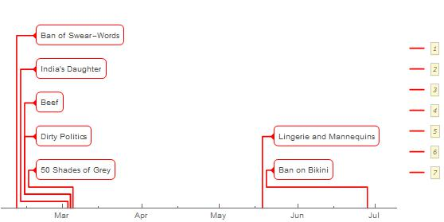

```python
image3
```

```python
from IPython.display import Image, HTML, display
from glob import glob
imagesList=''.join( ["<img style='width: 180px; margin: 0px; float: left; border: 1px solid black;' src='%s' />" % str(s)
                     for s in glob('*.jpg') ])
display(HTML(imagesList))
```

[figure not shown]

```python
os.chdir('C:\\Users\\user\\Desktop\\7th Sem Project\\Jupyter')
```

```python
os.listdir()
```

```
['.ipynb_checkpoints',
 'BanSectors.jpg',
 'BanTimeLine.jpg',
 'Components',
 'facets_with_custom_projection.png',
 'hist_new_stacked.png',
 'IndiaSelected.jpg',
 'Main.ipynb',
 'simple_violinplots.png',
 'StatesSelected.jpg']
```

```python
from glob import glob
glob('*.png')
```

```
['facets_with_custom_projection.png',
 'hist_new_stacked.png',
 'simple_violinplots.png']
```